# Reyna_Gomez_Research.Question

Lariece Reyna and Ariadna Gomez-lopez

2023-03-24

## Introduction:

In recent years, the topic of police brutality in highly-policed communities has become more prevalent as over-policing continues to be pervasive in communities of color, especially Black communities, and with over-policing comes higher rates of instances of police brutality where the level of force being used is not justified by the situation. This is seen in the many videos documented by civilians which has brought this issue to national headlines and showed how pervasive this problem is as people continue to lose their lives. The use of body cameras in police departments have begun to rise as people begin to discuss methods of reform that will hold more officers accountable for their actions, or prevent as much police injustice as possible in order to improve civilian perceptions of police. However, the effectiveness of these body cameras is unclear, as police brutality continues to be an issue. Looking at previous literature on the topic, we intend to argue that due to various factors such as decreasing complaints about police in civilian-police encounters, public opinions on body-worn cameras, and the spillover effects of body-worn cameras in encounters, that their effect is positive in reducing civilian complaints, as public opinion about body-worn cameras in highly-policed communities also seems relatively positive.

## Research Question:

How effective are body-worn cameras in decreasing police brutality in highly-policed communities?

## Literature Review:

In recent years, the topic of police brutality in highly-policed communities has become more prevalent as over-policing continues to be pervasive in communities of color, especially Black communities, and with over-policing comes higher rates of instances of police brutality where the level of force being used is not justified by the situation. This is seen in the many videos documented by civilians which has brought this issue to national headlines and showed how pervasive this problem is as people continue to lose their lives. The use of body cameras in police departments have begun to rise as people begin to discuss methods of reform that will hold more officers accountable for their actions, or prevent as much police injustice as possible in order to improve civilian perceptions of police. However, the effectiveness of these body cameras is unclear, as police brutality continues to be an issue. Looking at previous literature on the topic, we intend to argue that due to various factors such as decreasing complaints about police in civilian-police encounters, public opinions on body-worn cameras, and the spillover effects of body-worn cameras in encounters, that their effect is positive in reducing civilian complaints, as public opinion about body-worn cameras in highly-policed communities also seems relatively positive. To elaborate on this, Mummolo (2017) analyzes the effectiveness of modern policing tactics using millions of records of police-citizen interactions alongside officer interviews. He is evaluating the impact of a change to the protocol for stopping criminal suspects on police performance after the implementation of the procedure to report police reasons for stops, and which types of changes influence police behavior the most. He looked at weapon recovery rates during stops in order to investigate the reduction of unnecessary searches, as well as homicide rates after in relation to the reduction of stops. Through this, Mummolo discovered that procedural changes can quickly and dramatically alter officer behavior, suggesting that police reform strategies driven by psychological and personality-driven accounts are not as effective, as his research showed a correlation between the procedural change of reporting stops and the decreased amount of weapon recovery in stops which indicates it did in fact reduce unnecessary searches. We plan to build upon this research as we are looking at how to increase the effectiveness of policing tactics in administering the appropriate amount of force at the appropriate time. As Mummolo stated procedural changes are most effective at influencing police behavior, our research expands on this by specifically looking at police body-worn cameras (BWC) and whether this procedural change is effective enough in changing how officers treat citizens. Ariel et al. (2017) also addresses current research on civilian complaints about police, and then follows through with an analysis on the potential impacting factors behind BWCs on police-civilian encounters. Using police shifts as their unit of analysis, they look at results from a global, multisite randomized controlled trial on whether BWC use reduces citizens’ complaints. Its focus is more so on the effect of BWCs, stating that they found a reduction in complaints in pre–post comparisons, but found no significant differences when looking at post treatment comparisons or between the different sites. Our research builds on this as it goes more in-depth about the findings of the impacts of BWCs, factoring in another measurement besides complaints to give a more rigorous analysis on the influence of BWCs in civilian-police encounters. Extending on this article, we would be using other data, specifically in an area that is highly policed, to analyze how BWCs influence police-civilian encounters in highly-policed communities. Since this article gives a more rigorous analysis to their impacts, this would give us more information on how useful they are, and how they affect outcomes from these encounters. In a different article, the same researchers Ariel, Sutherland, and Henstock, et al. (2018) conducted a randomized control trial in ten different police departments. To collect data, they chose random and separate shifts where an officer would wear a body camera and another would not in order to see if the influence of self-awareness through body cameras affected their performance or influenced assaults against officers, which is what differs from their other work. They discovered that while body cameras increase individual chances of assault against an officer by 37%, overall in departments, assault was reduced by 61%. They also found that with officers who wore body cameras, complaints against officers reduced along with use of force and arrest rates. This is greatly connected with our research as it shows how force, arrests, and complaints reduce which is correlated with how we plan to measure police brutality as we will be focusing on complaints and use of force. We plan to expand on this by focusing on a highly-policed area, instead of a randomized sample, as this article does not take into account how factors such as the reported crime rates of an area may influence officers. The Braga, Barao, Zimmerman, et al. (2020) article examines the spillover effects of body-worn cameras (BWCs) in police-citizen encounters. It explains if BWCs have any significant impact on complaints from citizens, use of force from police, and police work activities such as arrests or officer-initiated calls. They are examining if any spillover effects from body-worn cameras have any influence over how citizens interact or behave with police officers in encounters with them. They found that BWCs do have statistical significance in reducing police complaints, there is no statistical significance on the effects of use of force while it does still reduce. Police activity saw no effects from BWCs, but it does deter both officers and citizens from inappropriate or illegal behaviors. Our research has to do with the effect of body-worn cameras in highly-policed communities, so our research will be building on this because it gives us a general idea of the outcomes of our research question, however we are also comparing racial differences in the amount of complaints and use of force. Our research will extend this article’s findings by conducting research on similar questions and hypotheses that are in line with the research question for this article. The Ray, Marsh, and Powelson (2017) article analyzes different perspectives on the effectiveness of BWCs from a civilian perspective through interviews. It takes into consideration the opinions from individuals in different racial groups (White, Black, Hispanic, Asian/Asian-American), and takes their perspectives and real-life experience with BWC into account. They found that respondents believed that BWC would either illuminate the difficulties of policing in support of the officer or it would create more transparency to hold officers more accountable for their actions in support of citizens. Our research question is about how effective BWCs are in highly-policed communities, and this will inevitably lead to different perspectives and opinions with how useful they actually are. This article is relevant because it shows us exactly what different members of different communities think of their effectiveness, which is one of the factors we’re looking for. Our research will extend this article by taking into account the interviewees’ experiences, and using that to conduct further research into the impact of BWCs in highly-policed communities, and how perceptions of BWCs change based on these lived experiences. We will also be comparing complaints among white and Black racial groups. The findings from the chosen research articles indicate that attitudes toward body-worn cameras in highly-policed communities have improved to a certain extent in recent years. Much of the literature concludes that there is a positive effect in reducing civilian complaints against police in encounters with them, and individuals from minoritized and highly-policed communities are in favor of them as they help promote police accountability. Yet multiple research studies validate the importance of looking more into police body-worn cameras. Therefore we plan to expand on existing research by focusing on a highly-policed community as our sample, and police injustice is being affected by body-worn cameras by looking at data before and after implementation of body-worn cameras. More specifically, our research question and data analysis will be examining how effective body-worn cameras are in decreasing civilian complaints and use of force in areas with higher rates of policing.


## Results:

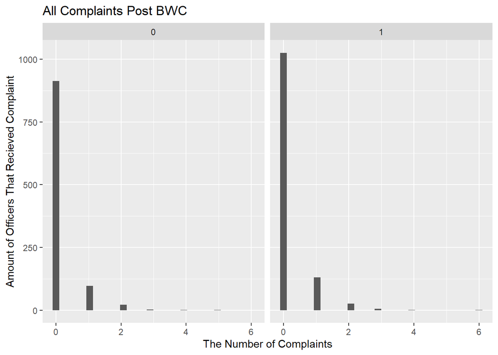

```
##
## Call:
## lm(formula = all_complaints_post ~ Z + all_complaints_pre + block_id,
##     data = officer)
##
## Residuals:
##     Min      1Q  Median      3Q     Max
## -0.4810 -0.1636 -0.1627 -0.1389  5.8369
##
## Coefficients:
##                     Estimate Std. Error t value Pr(>|t|)
## (Intercept)        1.386e-01  1.646e-02   8.417  < 2e-16 ***
## Z                  2.409e-02  2.069e-02   1.164  0.24447
## all_complaints_pre 5.177e-02  1.862e-02   2.780  0.00548 **
## block_id           7.740e-06  2.628e-05   0.294  0.76842
## ---
## Signif. codes:  0 '***' 0.001 '**' 0.01 '*' 0.05 '.' 0.1 ' ' 1
##
## Residual standard error: 0.4832 on 2220 degrees of freedom
## Multiple R-squared:  0.004199,   Adjusted R-squared:  0.002853
## F-statistic:  3.12 on 3 and 2220 DF,  p-value: 0.02507
```

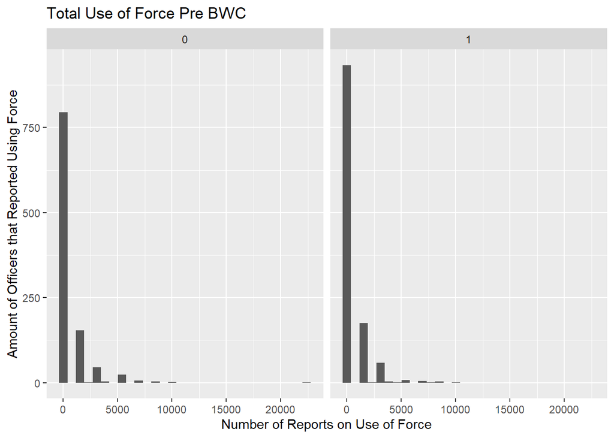

```
##
## Call:
## lm(formula = use_of_force_1000_rate_pre ~ Z, data = officer)
##
## Residuals:
##     Min      1Q  Median      3Q     Max
##  -654.8  -654.8  -538.9  -538.9 21742.6
##
## Coefficients:
##             Estimate Std. Error t value Pr(>|t|)
## (Intercept)   654.80      43.36  15.100   <2e-16 ***
## Z            -115.95      59.31  -1.955   0.0507 .
## ---
## Signif. codes:  0 '***' 0.001 '**' 0.01 '*' 0.05 '.' 0.1 ' ' 1
##
## Residual standard error: 1395 on 2222 degrees of freedom
## Multiple R-squared:  0.001717,   Adjusted R-squared:  0.001268
## F-statistic: 3.822 on 1 and 2222 DF,  p-value: 0.05071
```

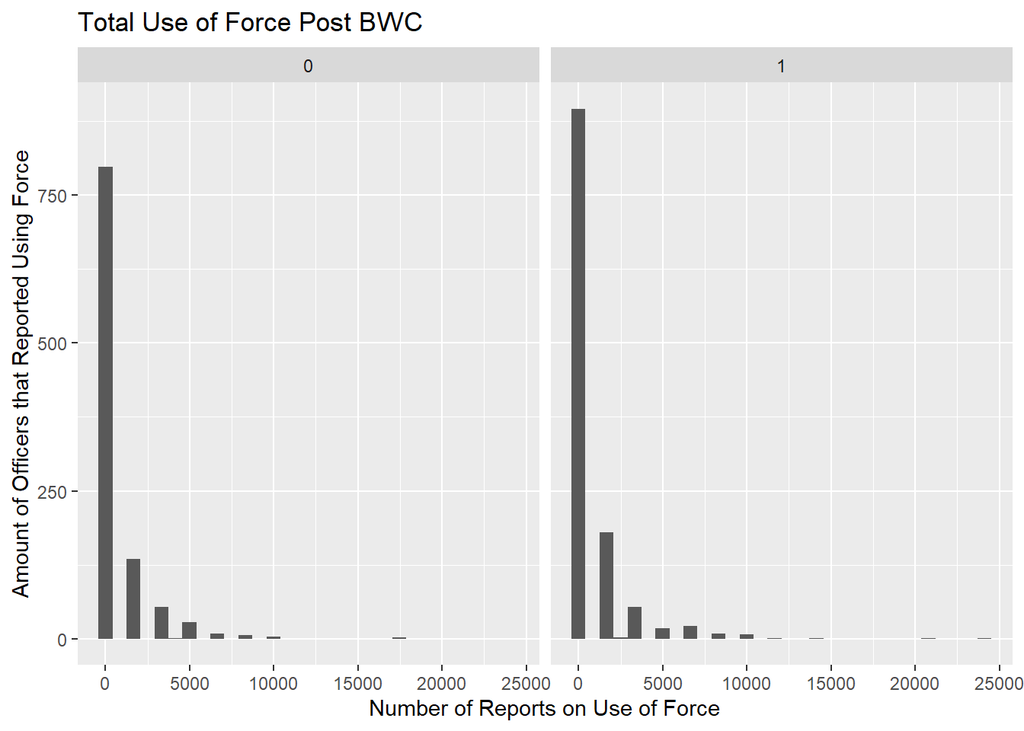

```
##
## Call:
## lm(formula = use_of_force_1000_rate_post ~ Z + use_of_force_1000_rate_pre +
##     block_id, data = officer)
##
## Residuals:
##     Min      1Q  Median      3Q     Max
## -7302.0  -618.6  -587.6  -498.8 22389.7
##
## Coefficients:
##                             Estimate Std. Error t value Pr(>|t|)
## (Intercept)                498.32303   62.38284   7.988 2.18e-15 ***
## Z                          109.96895   77.33858   1.422    0.155
## use_of_force_1000_rate_pre   0.29979    0.02751  10.897  < 2e-16 ***
## block_id                     0.08934    0.09818   0.910    0.363
## ---
## Signif. codes:  0 '***' 0.001 '**' 0.01 '*' 0.05 '.' 0.1 ' ' 1
##
## Residual standard error: 1804 on 2220 degrees of freedom
## Multiple R-squared:  0.05249,    Adjusted R-squared:  0.05121
## F-statistic: 40.99 on 3 and 2220 DF,  p-value: < 2.2e-16
```

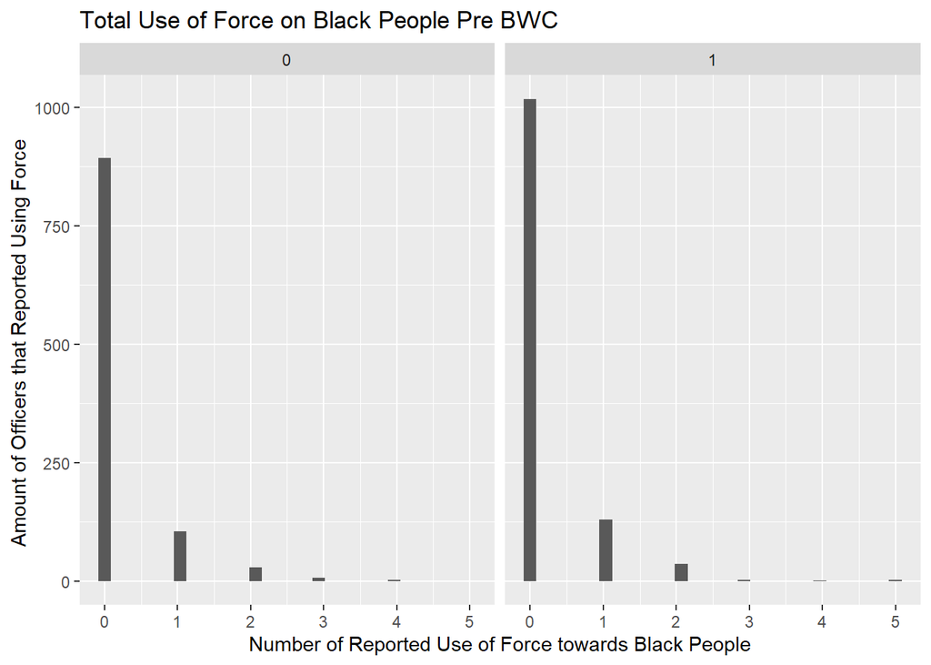

```
##
## Call:
## lm(formula = use_of_force_black_pre ~ Z, data = officer)
##
## Residuals:
##     Min      1Q  Median      3Q     Max
## -0.1892 -0.1892 -0.1865 -0.1865  4.8108
##
## Coefficients:
##             Estimate Std. Error t value Pr(>|t|)
## (Intercept) 0.186473   0.016359  11.399   <2e-16 ***
## Z           0.002761   0.022373   0.123    0.902
## ---
## Signif. codes:  0 '***' 0.001 '**' 0.01 '*' 0.05 '.' 0.1 ' ' 1
##
## Residual standard error: 0.5263 on 2222 degrees of freedom
## Multiple R-squared:  6.855e-06,  Adjusted R-squared:  -0.0004432
## F-statistic: 0.01523 on 1 and 2222 DF,  p-value: 0.9018
```

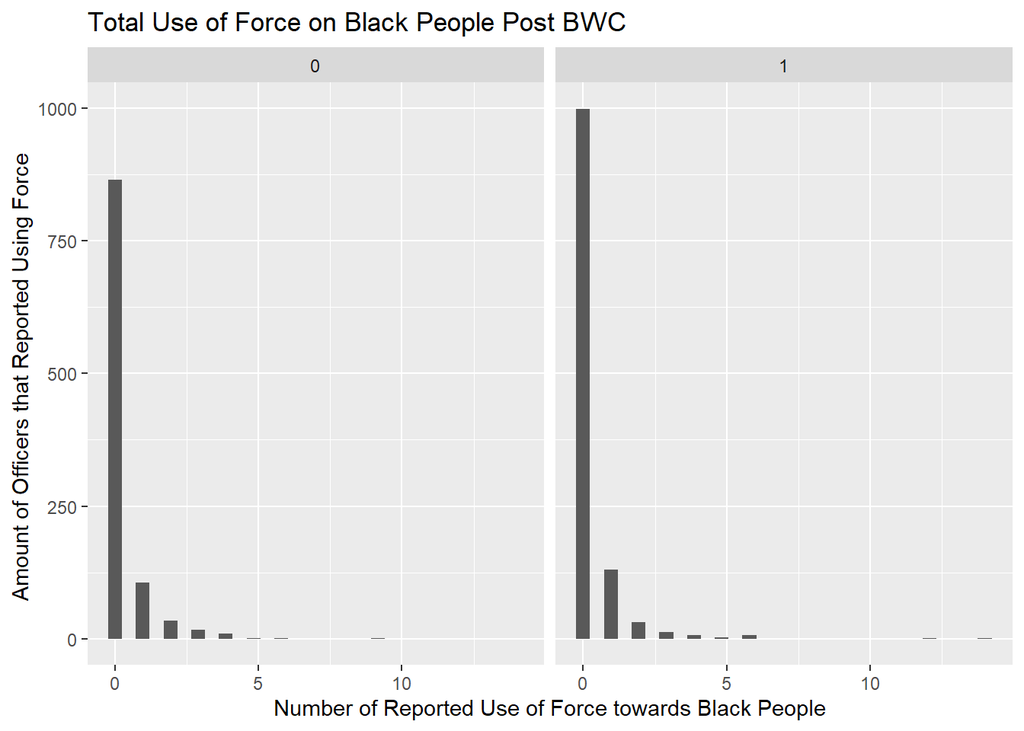

```
##
## Call:
## lm(formula = use_of_force_black_post ~ Z + use_of_force_black_pre +
##     block_id, data = officer)
##
## Residuals:
##     Min      1Q  Median      3Q     Max
## -1.2349 -0.2451 -0.2162 -0.2095 13.2927
##
## Coefficients:
##                          Estimate Std. Error t value Pr(>|t|)
## (Intercept)             2.127e-01  2.845e-02   7.476 1.10e-13 ***
## Z                      -5.803e-03  3.587e-02  -0.162   0.8715
## use_of_force_black_pre  2.038e-01  3.394e-02   6.006 2.22e-09 ***
## block_id                9.287e-05  4.569e-05   2.033   0.0422 *
## ---
## Signif. codes:  0 '***' 0.001 '**' 0.01 '*' 0.05 '.' 0.1 ' ' 1
##
## Residual standard error: 0.8376 on 2220 degrees of freedom
## Multiple R-squared:  0.01905,    Adjusted R-squared:  0.01773
## F-statistic: 14.37 on 3 and 2220 DF,  p-value: 2.835e-09
```

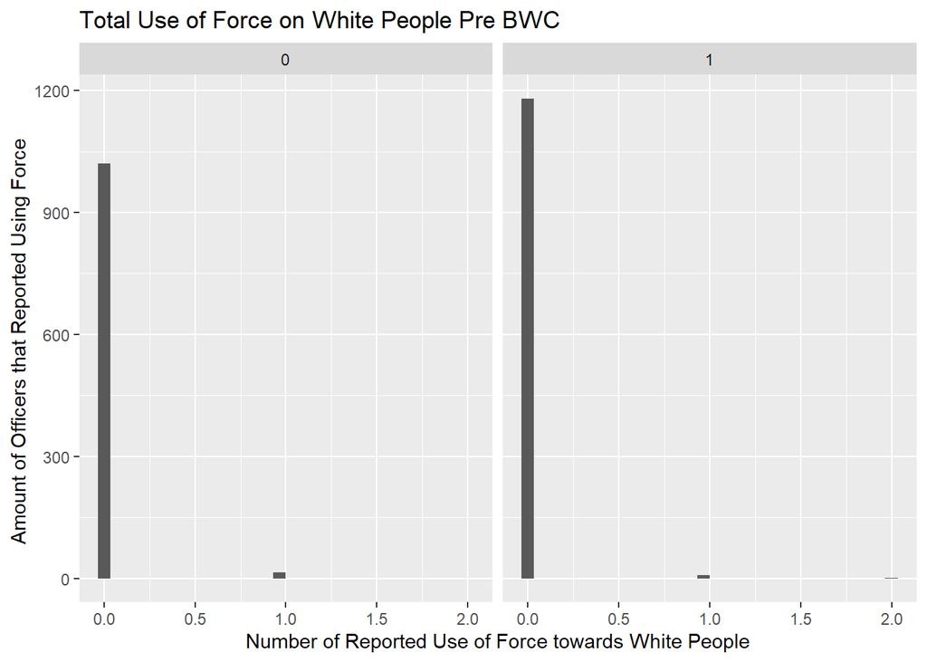

```
##
## Call:
## lm(formula = use_of_force_white_pre ~ Z, data = officer)
##
## Residuals:
##      Min       1Q   Median       3Q      Max
## -0.01353 -0.01353 -0.00841 -0.00841  1.99159
##
## Coefficients:
##              Estimate Std. Error t value Pr(>|t|)
## (Intercept)  0.013527   0.003345   4.044 5.43e-05 ***
## Z           -0.005116   0.004574  -1.118    0.263
## ---
## Signif. codes:  0 '***' 0.001 '**' 0.01 '*' 0.05 '.' 0.1 ' ' 1
##
## Residual standard error: 0.1076 on 2222 degrees of freedom
## Multiple R-squared:  0.0005627,  Adjusted R-squared:  0.0001129
## F-statistic: 1.251 on 1 and 2222 DF,  p-value: 0.2635
```

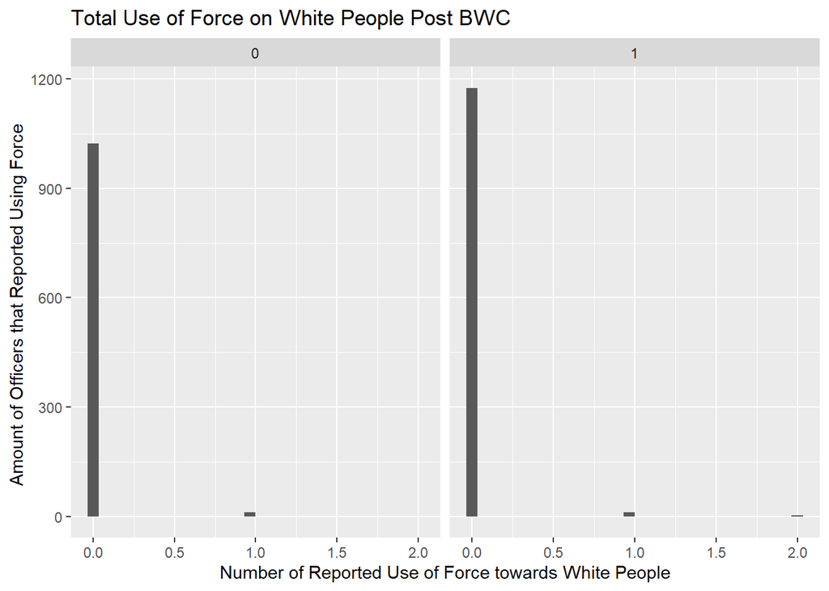

```
##
## Call:
## lm(formula = use_of_force_white_post ~ Z + use_of_force_white_pre +
##     block_id, data = officer)
##
## Residuals:
##      Min       1Q   Median       3Q      Max
## -0.05427 -0.01723 -0.01448 -0.01270  1.98320
##
## Coefficients:
##                          Estimate Std. Error t value Pr(>|t|)
## (Intercept)             1.498e-02  3.992e-03   3.752  0.00018 ***
## Z                       3.572e-03  5.104e-03   0.700  0.48413
## use_of_force_white_pre  2.620e-02  2.350e-02   1.115  0.26507
## block_id               -1.670e-05  6.469e-06  -2.581  0.00992 **
## ---
## Signif. codes:  0 '***' 0.001 '**' 0.01 '*' 0.05 '.' 0.1 ' ' 1
##
## Residual standard error: 0.1192 on 2220 degrees of freedom
## Multiple R-squared:  0.003657,   Adjusted R-squared:  0.002311
## F-statistic: 2.716 on 3 and 2220 DF,  p-value: 0.04328
```

## Bibliography:

Mummolo, Jonathan. “Modern Police Tactics, Police-Citizen Interactions, and the Prospects for Reform.” The Journal of Politics, vol. 80, no. 1, Jan. 2018, pp. 1–15, doi:https://doi.org/10.1086/694393.

Ariel, Barak, et al. “‘Contagious Accountability.’” Criminal Justice and Behavior, vol. 44, no. 2, Sept. 2016, pp. 293–316, doi:https://doi.org/10.1177/0093854816668218.

Ariel, Barak, Sutherland, A., Henstock, D. et al. “Paradoxical Effects of Self-Awareness of Being Observed: Testing the Effect of Police Body-Worn Cameras on Assaults and Aggression against Officers.” Journal of Experimental Criminology, vol. 14, no. 1, Dec. 2017, pp. 19–47, doi:https://doi.org/10.1007/s11292-017-9311-5.

Braga, Anthony A., et al. “Measuring the Direct and Spillover Effects of Body Worn Cameras on the Civility of Police–Citizen Encounters and Police Work Activities.” Journal of Quantitative Criminology, vol. 36, Oct. 2019, doi:https://doi.org/10.1007/s10940-019-09434-9.

Ray, Rashawn, et al. “Can Cameras Stop the Killings? Racial Differences in Perceptions of the Effectiveness of Body-Worn Cameras in Police Encounters,.” Sociological Forum, vol. 32, no. S1, July 2017, pp. 1032–50, doi:https://doi.org/10.1111/socf.12359.

Yokum, D. V., Ravishankar, A., Coppock, A., & Fieselmann, H. (2021, June 1). DC Body-Worn Camera Evaluation [officer_level_anon.csv]. https://doi.org/10.17605/OSF.IO/P6VUH